# Evaluating the Global Impact of Chronic Respiratory Diseases: A Comprehensive Analysis of Environmental Risk Factors

### 4.3.8 Partial Least Squares (PLS)

```r
# Blueprint 2

# perform 10-fold cross validation on a PCR model tuning the
# number of principal components to use as predictors from 1-20
set.seed(123)
cv_model_pls <- train(
  avg_crd_five ~ .,
  data = baked_train_subset2,
  method = "pls",
  trControl = trainControl(method = "cv", number = 10),
  preProcess = c("zv", "center", "scale"),   # remove zero variance features and standardize them
  tuneLength = 20
  )

# model with lowest RMSE
cv_model_pls$bestTune
```

| ncomp |
| --- |
| 7 |

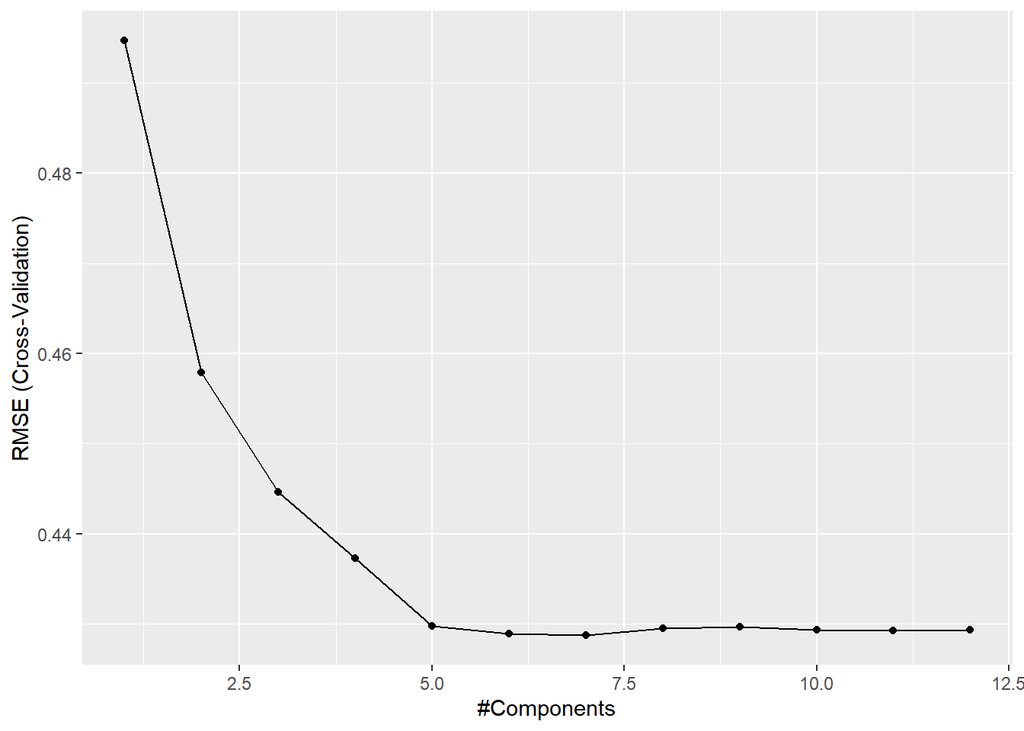

```r
##    ncomp
## 7    7

# plot cross-validated RMSE
ggplot(cv_model_pls)
```

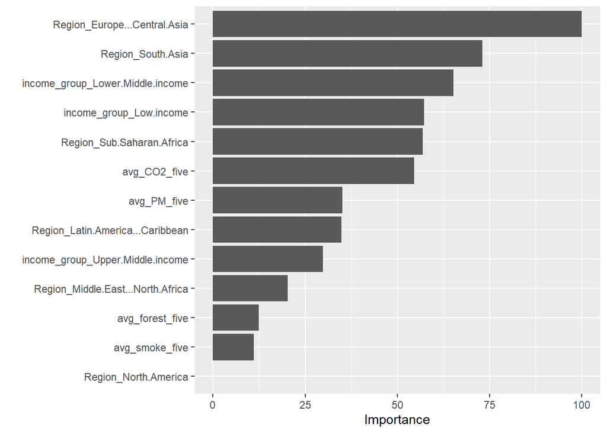

```r
library(vip)

vip(cv_model_pls, num_features = 13, method = "model")
```

## 4.4 Model Evaluation

```r
# Extract out of sample performance measures
summary(
  resamples(
    list(
      model4_lm = cv_lm4,
      model_pcr = cv_model_pcr,
      model_pls = cv_model_pls
)))
```

```
##
## Call:
## summary.resamples(object = resamples(list(model4_lm = cv_lm4, model_pcr
##  = cv_model_pcr, model_pls = cv_model_pls)))
##
## Models: model4_lm, model_pcr, model_pls
## Number of resamples: 10
##
## MAE
##                Min.   1st Qu.    Median      Mean   3rd Qu.      Max. NA's
## model4_lm 0.2318877 0.2874190 0.3591447 0.3464413 0.3958603 0.4381253    0
## model_pcr 0.2665319 0.3132168 0.4016719 0.3740861 0.4236223 0.4627806    0
## model_pls 0.2286347 0.2918504 0.3608493 0.3464573 0.3962998 0.4356329    0
##
## RMSE
##                Min.   1st Qu.    Median      Mean   3rd Qu.      Max. NA's
## model4_lm 0.3208905 0.3646566 0.4481185 0.4293212 0.4782777 0.5582027    0
## model_pcr 0.3620776 0.3959147 0.4797099 0.4627528 0.5222558 0.5306533    0
## model_pls 0.3233176 0.3650056 0.4470834 0.4287114 0.4788294 0.5534935    0
##
## Rsquared
##                Min.   1st Qu.    Median      Mean   3rd Qu.      Max. NA's
## model4_lm 0.2197078 0.5136173 0.6071367 0.5814052 0.6751059 0.7925349    0
## model_pcr 0.2749626 0.4290198 0.5138399 0.5128652 0.6193291 0.6992005    0
## model_pls 0.2280329 0.5161383 0.6061578 0.5826209 0.6766350 0.7886799    0
```

### 4.4.1 Final Model Selection - Model 4

$$\hat{Y} = 4.1532+ 0.0008forest +
0.0041PM2.5 + 0.0067smoking - 0.0369CO2-0.8894ECA -0.7035LAC-0.6460MENA
- 0.1548NA + 0.3677SA - 0.4668SSA + 0.5953 Low +0.4296 LoM +0.2092UpM$$

```r
finaltb1 <- list(lm4)
rows1 <- tribble(~term, ~'Model 2',
                '(East Asia & Pacific = 0)', '')

attr(rows1, 'position') <- c(11)
```

```r
finaltb_lm4 <- modelsummary(finaltb1,
             output = "huxtable",
             fmt = 4,
             esimate = "{estimate}{stars}",
             statistics = "std.error",
             stars = TRUE,
             gof_omit = 'AIC|BIC|RMSE|Log.Lik.|FE',
             add_rows = rows1,
             coef_rename = c("(Intercept)" = "Constant",
               "avg_forest_five" = "Forest area (% of land area)",
                             "avg_PM_five" = "Concentration of fine particulate matter (PM2.5)",
                             "avg_smoke_five" = "Share of adults smoking",
                             "avg_CO2_five" = "CO2 emission",
                             "Region_Europe...Central.Asia" = "Europe & Central Asia",
                             "Region_Latin.America...Caribbean" = "Latin America & Caribbean",
                             "Region_Middle.East...North.Africa" = "Middle East & North America",
                             "Region_North.America" = "North America",
                             "Region_South.Asia" = "South Asia",
                             "Region_Sub.Saharan.Africa" = "Sub Saharan Africa",
                             "income_group_Low.income" = "(High income = 0) Low income",
                             "income_group_Lower.Middle.income" = "Lower-middle income",
                             "income_group_Upper.Middle.income" = "Upper-middle income"))


finaltb_lm4
```

|  | (1) |
| --- | --- |
| Constant | 4.1532*** |
|  | (0.3598) |
| Forest area (% of land area) | 0.0008 |
|  | (0.0018) |
| Concentration of fine particulate matter (PM2.5) | 0.0041 |
|  | (0.0032) |
| Share of adults smoking | 0.0067 |
|  | (0.0051) |
| CO2 emission | -0.0369* |
|  | (0.0172) |
| (East Asia & Pacific = 0) |  |
| Europe & Central Asia | -0.8894*** |
|  | (0.1214) |
| Latin America & Caribbean | -0.7035*** |
|  | (0.1457) |
| Middle East & North America | -0.6460*** |
|  | (0.1664) |
| North America | -0.1548 |
|  | (0.3297) |
| South Asia | 0.3677+ |
|  | (0.2049) |
| Sub Saharan Africa | -0.4668** |
|  | (0.1514) |
| (High income = 0) Low income | 0.5953*** |
|  | (0.1604) |
| Lower-middle income | 0.4296*** |
|  | (0.1170) |
| Upper-middle income | 0.2092* |
|  | (0.1028) |
| Num.Obs. | 144 |
| R2 | 0.639 |
| R2 Adj. | 0.603 |
| F | 17.687 |
| + p < 0.1, * p < 0.05, ** p < 0.01, *** p < 0.001 |  |

# 5 **Discussion and Conclusion**

## 5.1 Descriptive Results discussion

### 5.1.1 Air-pollution variables

With only eight countries, **South Asia** stands out with the **highest** CRD death rate, averaging 109 per 100,000 people, surpassing the overall average of 44 per 100,000 people. Following closely, the East Asia and Pacific region exhibits the second-highest CRD incidence, with 79,000 cases on average, followed by Sub-Saharan Africa with 52,000 reported cases. Having only two countries, North America records 31,000 CRD cases, while the Middle East & North Africa, Latin America & Caribbean, and Europe & Central Asia report 30,000, 28,000, and 24,000 individuals affected by CRD, respectively.

Examining mean and median values reveals that the **average forest area and PM2.5 concentrations** display very **slight positive skewness, approaching normal distribution.** Conversely, the **average share of adults** smoking displays a **minimal negative skewness**, with the mean (22) slightly lower than the median (23).

Conversely, the distribution of **average CO2 emissions is highly positively skewed**, as indicated by a substantial difference between the mean (178,243,370) and the median (10,788,440). Consequently, addressing this skewness through log transformation is essential before proceeding with regression modelling.

### 5.1.2 Income level distribution

Regarding income distribution, the majority of **European & Asia Pacific** countries primarily fall into high or upper-middle income categories, accounting for 61% and 27% of countries, respectively, making them the most economically prosperous. Similarly, **North America** is characterized as a high-income region, albeit consisting of only two nations.

Within **Latin America & Caribbean**, a significant portion of countries falls into the upper-income category, with 61% and 24% being upper-middle income and high income. The income distribution in the **Middle East & North Africa** region is relatively diverse, with most countries positioned in the lower-middle income category or higher.

The East Asia & Pacific region mainly comprises countries in the middle-income bracket, comprising 73% (43% lower-middle income and 30% upper-middle income). In contrast, **South Asia and Sub-Saharan Africa** predominantly consist of low and lower-middle income countries, with very few high-income nations, making them the least economic prosperity.

## 5.2 Predictive Results discussion

To enhance Model 4, we explored PCR and PLS models. Model 4 excelled with the lowest MAE (0.3464), while the PLS model outperformed in RMSE (0.4287) and R-squared (0.5826). However, Model 4 is favored for its interpretability, a critical aspect in addressing our research problem.

Examining Region, South Asia. solely stood out with a positive coefficient, indicating that there are approximately 36,773 **more** CRD cases than in the East Asia & Pacific region on average. Other regions, except North America, exhibit **lower** CRD rates than East Asia & Pacific, with Sub-Saharan**(46,678), Middle East***(64,597), Latin America***(70,353), and Europe***(88,942) following in decreasing order.

## 5.3 Conclusion

In conclusion, Carbon dioxide emissions stemming from fossil fuel burning from industrial serve as the most significant factor contributing to CRD death rate. However, the negative relationship is not what is expected as logically the higher CO2 emissions should contribute to higher CRD death rate. Our results also show that South Asia has the highest CRD death rate compared to the rest of the world and is proven by a lot of studies. This can be explained by the fact that South Asia consists of low to lower-middle income countries meaning that health resources for CRD treatments are not as advanced as high income countries, considering that CRD is incurable.

To combat this, governments should consider delegating some funding to improve medical treatments, allowing citizens to get routine medical examinations to detect early symptoms. Additionally, since renewable projects are risky, government especially in lower income countries should also consider providing policy support (i.e implying green finance loan) to encourages private investment in the green energy industry to take on environmentally-positive initiatives (Ehsan Rasoulinezhad, Farhad Taghizadeh-Hesary, and Farzad Taghizadeh-Hesary 2020).

Due to the lack of resources and time, our variables are not 100% representative of air pollution. Other considerations like CO, NO, and NO2, may be included. Moreover, one limitation of our analysis is that we only consider the environmental factors that are related to air pollution. Biological and physiological factors such as age, gender, BMI, blood pressure, may be taken into account in future studies.

# References

Asitdubey. 2020. “Bias-Variance Trade-Off,” July. https://medium.com/analytics-vidhya/bias-variance-trade-off-2f3146700f5a#:~:text=The%20goal%20of%20any%20supervised,should%20achieve%20good%20prediction%20performance.&text=A%20low%20bias%20and%20high,insights%20given%20their%20respective%20dataset.

Ehsan Rasoulinezhad, Farhad Taghizadeh-Hesary, and Farzad Taghizadeh-Hesary. 2020. “How Is Mortality Affected by Fossil Fuel Consumption, CO2 Emissions and Economic Factors in CIS Region?” May. https://doi.org/10.3390/en13092255.

Emerson Augusto Baptista, Sudeshna Dey, and Soumya Pal. 2021. “Chronic Respiratory Disease Mortality and Its Associated Factors in Selected Asian Countries: Evidence from Panel Error Correction Model.” *BMC Public Health* 21 (1). https://doi.org/https://doi.org/10.1186/s12889-020-10042-7.

Frick, Hannah, Fanny Chow, Max Kuhn, Michael Mahoney, Julia Silge, and Hadley Wickham. 2022. *Rsample: General Resampling Infrastructure*. https://CRAN.R-project.org/package=rsample.

GBD 2019 Chronic Respiratory Diseases Collaborators. 2019. “Global Burden of Chronic Respiratory Diseases and Risk Factors, 19902019: An Update from the Global Burden of Disease Study 2019.” https://doi.org/doi: 10.1016/j.eclinm.2023.101936.

GBD Chronic Respiratory Disease Collaborators. 2020. “Prevalence and Attributable Health Burden of Chronic Respiratory Diseases, 19902017: A Systematic Analysis for the Global Burden of Disease Study 2017.” *Elsevier BV* 8 (6): 585596. https://doi.org/10.1016/s2213-2600(20)30105-3.

Giulia Squillacioti, Valeria Bellisario, Stefano Levra, Pavilio Piccioni, and Roberto Bono. 2017. “Greenness Availability and Respiratory Health in a Population of Urbanised Children in North-Western Italy.” *MDPI* 17 (1): 108. https://doi.org/10.3390/ijerph17010108.

Our World in Data. 2021. “Chronic Respiratory Diseases Death Rate.” https://ourworldindata.org/grapher/respiratory-disease-death-rate?tab=chart&facet=none.

———. 2022. “CO2 Emissions.” https://ourworldindata.org/co2-emissions.

———. 2023. “Smoking.” https://ourworldindata.org/smoking.

R Core Team. 2022. *R: A Language and Environment for Statistical Computing*. Vienna, Austria: R Foundation for Statistical Computing. https://www.R-project.org/.

The World Bank. 2022. “The World by Income and Region.” https://datatopics.worldbank.org/world-development-indicators/the-world-by-income-and-region.html.

Wassim W Labaki, and MeiLan K Han. 2020. “Chronic Respiratory Diseases: A Global View.” *Elsevier BV* 8 (6): 531–33. https://doi.org/10.1016/s2213-2600(20)30157-0.

World Bank. 2023. “Forest Area (.” https://data.worldbank.org/indicator/AG.LND.FRST.ZS.

World Health Organization. 2023. “SDG Indicator 11.6.2 Concentrations of Fine Particulate Matter (PM2.5).” https://www.who.int/data/gho/data/indicators/indicator-details/GHO/concentrations-of-fine-particulate-matter-(pm2-5).

———. n.d. “Chronic Respiratory Diseases.” https://www.who.int/health-topics/chronic-respiratory-diseases#tab=tab_1.

Xu-Qin Jiang, Xiao-Dong Mei, and Di Feng. 2016. “Air Pollution and Chronic Airway Diseases: What Should People Know and Do?” *PubMed* 8 (1): E31E40. https://doi.org/10.3978/j.issn.2072-1439.2015.11.50.